# Lab 4 - Linear Regression

Your name here

This assignment is based on the material covered in James et al. We will subsequently open up solutions to the problem sets.

## Exercise 4.1

This question involves the use of multiple linear regression on the `Auto` data set. So load the data set from the `ISLR` package first.

If the following code chunk returns an error, you most likely have to install the `ISLR` package first. Use `install.packages("ISLR2")` if this is the case.

```r
data('Auto', package = "ISLR2")

as_tibble(Auto)
```

```
## # A tibble: 392 × 9
##      mpg cylinders displacement horsepower weight acceleration  year origin
##    <dbl>     <int>        <dbl>      <int>  <int>        <dbl> <int>  <int>
##  1    18         8          307        130   3504         12      70      1
##  2    15         8          350        165   3693         11.5    70      1
##  3    18         8          318        150   3436         11      70      1
##  4    16         8          304        150   3433         12      70      1
##  5    17         8          302        140   3449         10.5    70      1
##  6    15         8          429        198   4341         10      70      1
##  7    14         8          454        220   4354          9      70      1
##  8    14         8          440        215   4312          8.5    70      1
##  9    14         8          455        225   4425         10      70      1
## 10    15         8          390        190   3850          8.5    70      1
## # ℹ 382 more rows
## # ℹ 1 more variable: name <fct>
```

1. Produce a scatterplot matrix which includes all of the variables in the data set.

We will exclude `origin` as it is not numeric.

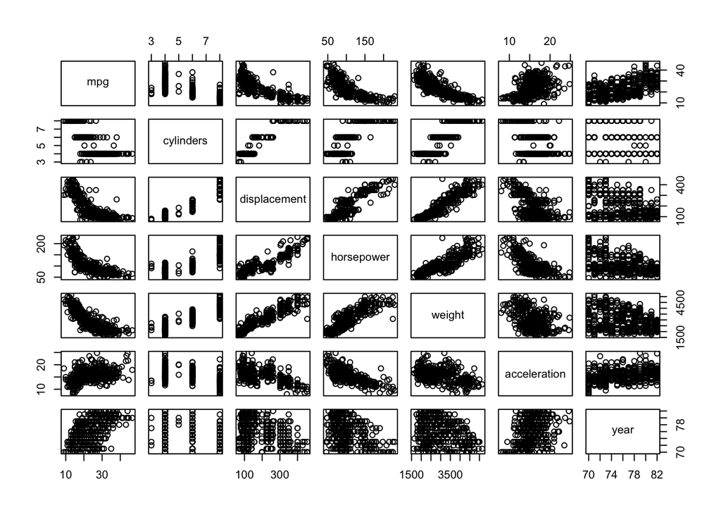

```r
pairs(Auto[,1:7])
```

2. Compute the matrix of correlations between the variables using the function `cor()`. You will need to exclude the `name` variable, which is qualitative.

We will also exclude origin.

```r
cor(Auto[,1:7])
```

```
##                     mpg  cylinders displacement horsepower     weight
## mpg           1.0000000 -0.7776175   -0.8051269 -0.7784268 -0.8322442
## cylinders    -0.7776175  1.0000000    0.9508233  0.8429834  0.8975273
## displacement -0.8051269  0.9508233    1.0000000  0.8972570  0.9329944
## horsepower   -0.7784268  0.8429834    0.8972570  1.0000000  0.8645377
## weight       -0.8322442  0.8975273    0.9329944  0.8645377  1.0000000
## acceleration  0.4233285 -0.5046834   -0.5438005 -0.6891955 -0.4168392
## year          0.5805410 -0.3456474   -0.3698552 -0.4163615 -0.3091199
##              acceleration       year
## mpg             0.4233285  0.5805410
## cylinders      -0.5046834 -0.3456474
## displacement   -0.5438005 -0.3698552
## horsepower     -0.6891955 -0.4163615
## weight         -0.4168392 -0.3091199
## acceleration    1.0000000  0.2903161
## year            0.2903161  1.0000000
```

3. Use the `lm()` function to perform a multiple linear regression with `mpg` as the response and all other variables except `name` as the predictors. Use the `summary()` function to print the results. Comment on the output. For instance:
   1. Is there a relationship between the predictors and the response?

The F-Statistic is statistically significant at all conventional thresholds. This means there is evidence that our model performs better than an intercept only model.

```r
linear.model.auto <-
  Auto %>%
  select(-name) %>%
  mutate(origin = case_when(origin == 1 ~ 'American',
                            origin == 2 ~ 'European',
                            origin == 3 ~ 'Japanese')) %>%
  lm(mpg ~ ., data = .)

summary(linear.model.auto)
```

```
##
## Call:
## lm(formula = mpg ~ ., data = .)
##
## Residuals:
##     Min      1Q  Median      3Q     Max
## -9.0095 -2.0785 -0.0982  1.9856 13.3608
##
## Coefficients:
##                  Estimate Std. Error t value Pr(>|t|)
## (Intercept)    -1.795e+01  4.677e+00  -3.839 0.000145 ***
## cylinders      -4.897e-01  3.212e-01  -1.524 0.128215
## displacement    2.398e-02  7.653e-03   3.133 0.001863 **
## horsepower     -1.818e-02  1.371e-02  -1.326 0.185488
## weight         -6.710e-03  6.551e-04 -10.243  < 2e-16 ***
## acceleration    7.910e-02  9.822e-02   0.805 0.421101
## year            7.770e-01  5.178e-02  15.005  < 2e-16 ***
## originEuropean  2.630e+00  5.664e-01   4.643 4.72e-06 ***
## originJapanese  2.853e+00  5.527e-01   5.162 3.93e-07 ***
## ---
## Signif. codes:  0 '***' 0.001 '**' 0.01 '*' 0.05 '.' 0.1 ' ' 1
##
## Residual standard error: 3.307 on 383 degrees of freedom
## Multiple R-squared:  0.8242, Adjusted R-squared:  0.8205
## F-statistic: 224.5 on 8 and 383 DF,  p-value: < 2.2e-16
```

```
ii. Which predictors appear to have a statistically significant relationship to the response?
```

Numeric variables such as `displacement`, `weight`, and `year` are statistically significant. European and Japanese made cars also have significantly higher `mpg` than American made cars.

```r
library(broom)

linear.model.auto %>%
  tidy() %>%
  filter(term != '(Intercept)',
         p.value < 0.05) %>%
  pull(term)
```

```
## [1] "displacement"   "weight"         "year"           "originEuropean"
## [5] "originJapanese"
```

```
iii. What does the coefficient for the `year` variable suggest?
```

Holding all other variables constant, when `year` increases by 1 unit, we predict a 0.78 point increase in `mpg`.

```r
linear.model.auto %>%
  tidy() %>%
  filter(term == 'year') %>%
  pull(estimate)
```

```
## [1] 0.7770269
```

4. Use the `plot()` function to produce diagnostic plots of the linear regression fit. Comment on any problems you see with the fit. Do the residual plots suggest any unusually large outliers? Does the leverage plot identify any observations with unusually high leverage?

Data point 14 has high leverage yet comparatively not high residual values.

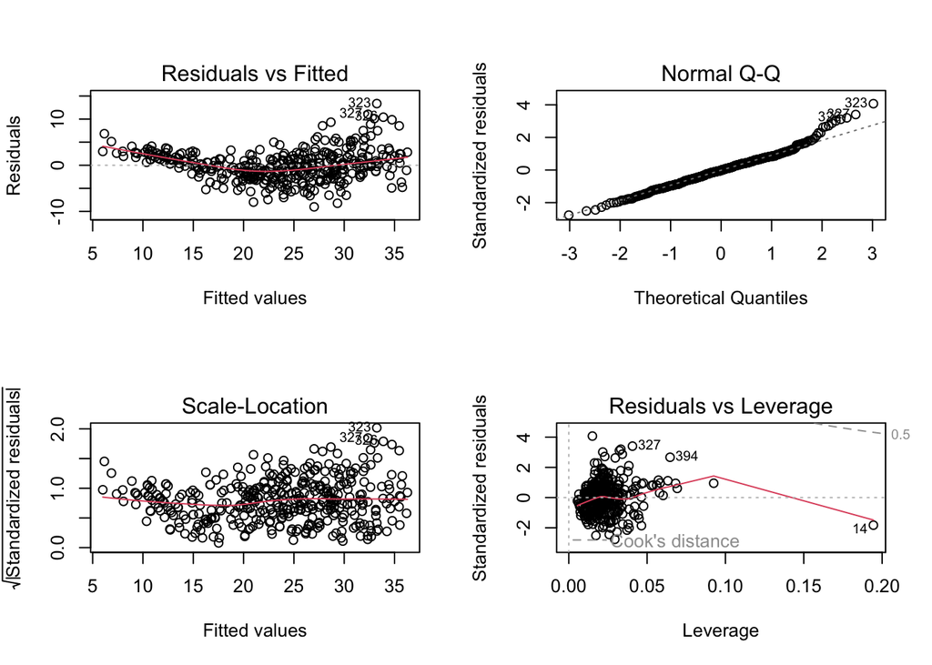

```r
par(mfrow = c(2, 2))

plot(linear.model.auto)
```

```r
Auto[14,]
```

```
##    mpg cylinders displacement horsepower weight acceleration year origin
## 14  14         8          455        225   3086           10   70      1
##                       name
## 14 buick estate wagon (sw)
```

5. Use the `*` and `:` symbols to fit linear regression models with interaction effects. Do any interactions appear to be statistically significant?

First, let’s look at all two-way interactions to see which best fits the data. Don’t worry if you can’t understand the code yet, this is for the sake of completeness. For simplicity’s sake, I will remove `origin`. `combn` helps us develop unique combinations. From there, we turn this information into a data frame and create a formula string. Next, we nest the auto data set so that each formula has it’s own data frame. We then build models for each interaction and calculate the r-squared values. It turns out that `weight * year` has the highest r-squared so we will analyse it,

```r
features <- colnames(Auto)[2:7]

features %>%
  combn(m = 2) %>%
  t() %>%
  as_tibble() %>%
  transmute(formula = paste('mpg ~', V1, '*', V2 )) %>%
  crossing(nest(Auto)) %>%
  mutate(model = map2(.x = formula, .y = data, .f = ~ lm(as.formula(.x), data = .y)),
         r.squared = map_dbl(.x = model, .f = ~ glance(.x)$r.squared)) %>%
  arrange(desc(r.squared))
```

```
## # A tibble: 15 × 4
##    formula                           data               model  r.squared
##    <chr>                             <list>             <list>     <dbl>
##  1 mpg ~ weight * year               <tibble [392 × 9]> <lm>       0.834
##  2 mpg ~ displacement * year         <tibble [392 × 9]> <lm>       0.774
##  3 mpg ~ horsepower * year           <tibble [392 × 9]> <lm>       0.752
##  4 mpg ~ horsepower * weight         <tibble [392 × 9]> <lm>       0.748
##  5 mpg ~ displacement * horsepower   <tibble [392 × 9]> <lm>       0.747
##  6 mpg ~ cylinders * horsepower      <tibble [392 × 9]> <lm>       0.727
##  7 mpg ~ displacement * weight       <tibble [392 × 9]> <lm>       0.727
##  8 mpg ~ cylinders * year            <tibble [392 × 9]> <lm>       0.722
##  9 mpg ~ cylinders * weight          <tibble [392 × 9]> <lm>       0.717
## 10 mpg ~ weight * acceleration       <tibble [392 × 9]> <lm>       0.706
## 11 mpg ~ horsepower * acceleration   <tibble [392 × 9]> <lm>       0.681
## 12 mpg ~ cylinders * displacement    <tibble [392 × 9]> <lm>       0.677
## 13 mpg ~ displacement * acceleration <tibble [392 × 9]> <lm>       0.677
## 14 mpg ~ cylinders * acceleration    <tibble [392 × 9]> <lm>       0.610
## 15 mpg ~ acceleration * year         <tibble [392 × 9]> <lm>       0.408
```

```r
interaction.model <-
  Auto %>%
  lm(mpg ~ weight * year, data = .)

summary(interaction.model)
```

```
##
## Call:
## lm(formula = mpg ~ weight * year, data = .)
##
## Residuals:
##     Min      1Q  Median      3Q     Max
## -8.0397 -1.9956 -0.0983  1.6525 12.9896
##
## Coefficients:
##               Estimate Std. Error t value Pr(>|t|)
## (Intercept) -1.105e+02  1.295e+01  -8.531 3.30e-16 ***
## weight       2.755e-02  4.413e-03   6.242 1.14e-09 ***
## year         2.040e+00  1.718e-01  11.876  < 2e-16 ***
## weight:year -4.579e-04  5.907e-05  -7.752 8.02e-14 ***
## ---
## Signif. codes:  0 '***' 0.001 '**' 0.01 '*' 0.05 '.' 0.1 ' ' 1
##
## Residual standard error: 3.193 on 388 degrees of freedom
## Multiple R-squared:  0.8339, Adjusted R-squared:  0.8326
## F-statistic: 649.3 on 3 and 388 DF,  p-value: < 2.2e-16
```

We find that the interaction variable is negative and significant. To see what this means, let’s create new data looking at `weight` in the years 1970 and 1982. We will also include an “additive” model to use as a comparison. We see that when we only include both variables without an interaction, the slopes for weight at 1970 and 1982 are identical. However, if we include an interaction, we see that the rate at which heavier cars lose efficiency becomes greater in 1982 when compared to 1970.

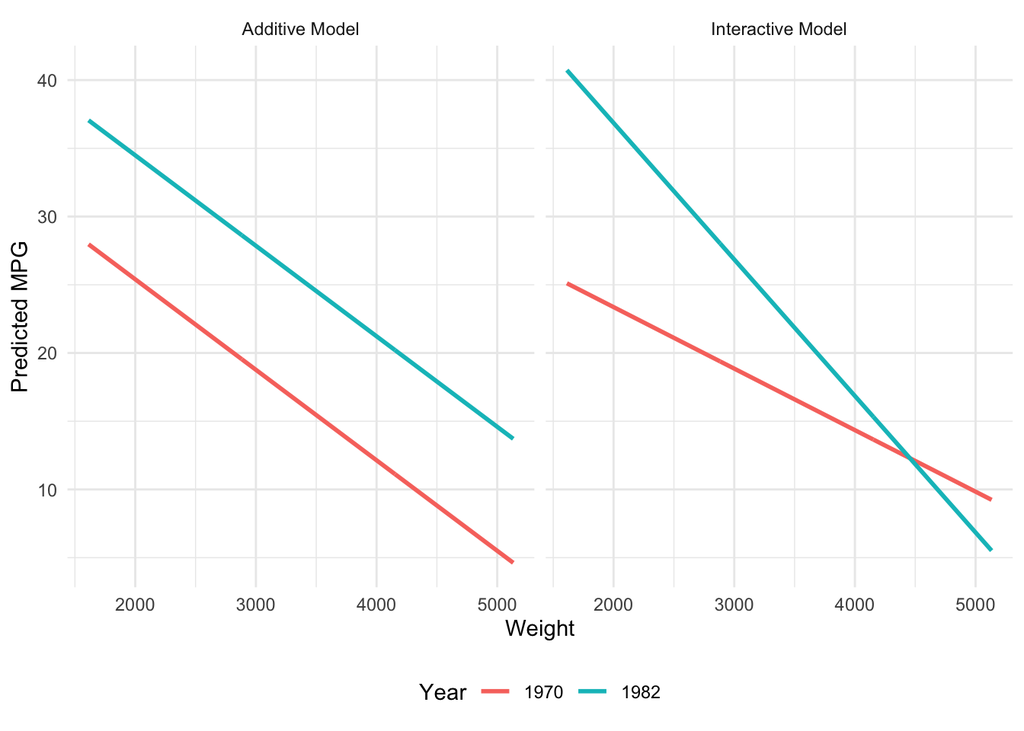

```r
additive.model <-
  Auto %>%
  lm(mpg ~ weight + year, data = .)

crossing(year = c(70, 82),
         weight = seq(min(Auto$weight), max(Auto$weight), 10)) %>%
  bind_cols(.pred_interactive = predict(interaction.model, newdata = .),
            .pred_additive = predict(additive.model, newdata = .)) %>%
  pivot_longer(starts_with('.pred'), names_to = 'model', values_to = '.pred') %>%
  ggplot(aes(weight, .pred, colour = as.factor(paste0('19',year)))) +
  facet_wrap(. ~
               str_c(
                 str_to_sentence(
                   str_remove(model, '.pred_')
                   ), ' Model'
                 )
             ) +
  geom_line(linewidth = 1) +
  theme_minimal() +
  theme(legend.position = 'bottom') +
  labs(x = 'Weight', y = 'Predicted MPG', colour = 'Year')
```

6. Try a few different transformations of the variables, such as $log(X)$, $\sqrt{X}$, $X^2$. Comment on your findings.

Let’s try adding a squared term for `displacement`. The regression results suggest that the linear term for `displacement` (a.k.a. `poly(displacement, 2)1`) is negative and significant, as we predicted. However, the squared term for `displacement` (a.k.a. `poly(displacement, 2)2`) is positive and significant. This suggests a $U$ shaped relationship. To see this relationship graphically, let’s plot this regression line.

```r
poly.model <-
  Auto %>%
  lm(mpg ~ poly(displacement,2), data = .)

summary(poly.model)
```

```
##
## Call:
## lm(formula = mpg ~ poly(displacement, 2), data = .)
##
## Residuals:
##      Min       1Q   Median       3Q      Max
## -15.2165  -2.2404  -0.2508   2.1094  20.5158
##
## Coefficients:
##                         Estimate Std. Error t value Pr(>|t|)
## (Intercept)              23.4459     0.2205 106.343  < 2e-16 ***
## poly(displacement, 2)1 -124.2585     4.3652 -28.466  < 2e-16 ***
## poly(displacement, 2)2   31.0895     4.3652   7.122 5.17e-12 ***
## ---
## Signif. codes:  0 '***' 0.001 '**' 0.01 '*' 0.05 '.' 0.1 ' ' 1
##
## Residual standard error: 4.365 on 389 degrees of freedom
## Multiple R-squared:  0.6888, Adjusted R-squared:  0.6872
## F-statistic: 430.5 on 2 and 389 DF,  p-value: < 2.2e-16
```

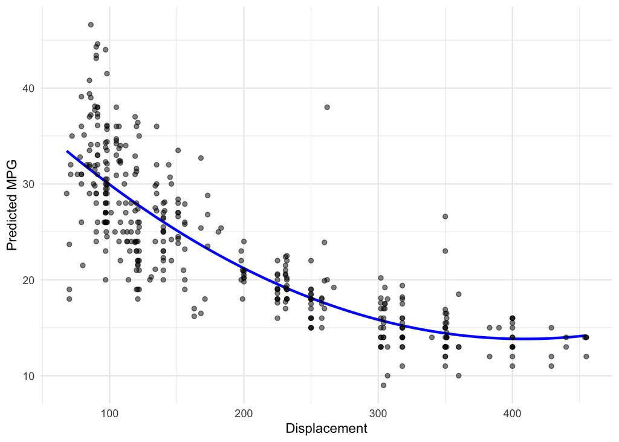

```r
tibble(displacement = seq(min(Auto$displacement), max(Auto$displacement), 1)) %>%
  bind_cols(.pred = predict(poly.model, newdata = .)) %>%
  ggplot(aes(displacement, .pred)) +
  geom_line(size = 1, colour = 'blue') +
  geom_point(data = Auto, aes(displacement, mpg), alpha = 0.5) +
  theme_minimal() +
  labs(x = 'Displacement', y = 'Predicted MPG')
```

## Exercise 4.2

This question should be answered using the `Carseats` dataset from the `ISLR` package. So load the data set from the `ISLR` package first.

```r
data("Carseats", package = "ISLR2")
```

1. Fit a multiple regression model to predict `Sales` using `Price`, `Urban`, and `US`.

```r
Carseats %>%
  lm(Sales ~ Price + Urban + US, data = .) %>%
  summary()
```

```
##
## Call:
## lm(formula = Sales ~ Price + Urban + US, data = .)
##
## Residuals:
##     Min      1Q  Median      3Q     Max
## -6.9206 -1.6220 -0.0564  1.5786  7.0581
##
## Coefficients:
##              Estimate Std. Error t value Pr(>|t|)
## (Intercept) 13.043469   0.651012  20.036  < 2e-16 ***
## Price       -0.054459   0.005242 -10.389  < 2e-16 ***
## UrbanYes    -0.021916   0.271650  -0.081    0.936
## USYes        1.200573   0.259042   4.635 4.86e-06 ***
## ---
## Signif. codes:  0 '***' 0.001 '**' 0.01 '*' 0.05 '.' 0.1 ' ' 1
##
## Residual standard error: 2.472 on 396 degrees of freedom
## Multiple R-squared:  0.2393, Adjusted R-squared:  0.2335
## F-statistic: 41.52 on 3 and 396 DF,  p-value: < 2.2e-16
```

2. Provide an interpretation of each coefficient in the model. Be careful – some of the variables in the model are qualitative!

`Price`: A one-unit increase in price is estimated to have a 0.05 point (or a 50 seat) decrease in sales, holding all other variables constant. This estimate is statistically significant at all thresholds.

`Urban`: Urban stores are estimated to have a 0.02 point (or a 20 seat) decrease in sales relative to rural stores, holding all other variables constant. However, this estimate fails to reach conventional levels of statistical significance.

`US`: Stores located in the United States are estimated to have a 1.2 point (or a 1200 seat) increase in sales relative to stores in other countries. This estimate is statistically significant at all thresholds.

3. Write out the model in equation form, being careful to handle the qualitative variables properly.

$$\hat{Sales} = 13.04 - 0.05\:Price -
0.02\:Urban_{\:=\:YES} + 1.2\:US_{\:=\:YES}$$

4. For which of the predictors can you reject the null hypothesis $H_0 : \beta_j =0$?

`Price` and `US` are statistically significant at all thresholds.

5. On the basis of your response to the previous question, fit a smaller model that only uses the predictors for which there is evidence of association with the outcome.

```r
Carseats %>%
  lm(Sales ~ Price + US, data = .) %>%
  summary()
```

```
##
## Call:
## lm(formula = Sales ~ Price + US, data = .)
##
## Residuals:
##     Min      1Q  Median      3Q     Max
## -6.9269 -1.6286 -0.0574  1.5766  7.0515
##
## Coefficients:
##             Estimate Std. Error t value Pr(>|t|)
## (Intercept) 13.03079    0.63098  20.652  < 2e-16 ***
## Price       -0.05448    0.00523 -10.416  < 2e-16 ***
## USYes        1.19964    0.25846   4.641 4.71e-06 ***
## ---
## Signif. codes:  0 '***' 0.001 '**' 0.01 '*' 0.05 '.' 0.1 ' ' 1
##
## Residual standard error: 2.469 on 397 degrees of freedom
## Multiple R-squared:  0.2393, Adjusted R-squared:  0.2354
## F-statistic: 62.43 on 2 and 397 DF,  p-value: < 2.2e-16
```

6. How well do the models in (a) and (e) fit the data?

If we compare model summaries, we note two things. $R^2$ values are the same (to 4 decimal places). However adjusted $R^2$ values are slightly higher for (e) when compared to (a).

```r
Carseats %>%
  lm(Sales ~ Price + Urban + US, data = .) %>%
  summary()
```

```
##
## Call:
## lm(formula = Sales ~ Price + Urban + US, data = .)
##
## Residuals:
##     Min      1Q  Median      3Q     Max
## -6.9206 -1.6220 -0.0564  1.5786  7.0581
##
## Coefficients:
##              Estimate Std. Error t value Pr(>|t|)
## (Intercept) 13.043469   0.651012  20.036  < 2e-16 ***
## Price       -0.054459   0.005242 -10.389  < 2e-16 ***
## UrbanYes    -0.021916   0.271650  -0.081    0.936
## USYes        1.200573   0.259042   4.635 4.86e-06 ***
## ---
## Signif. codes:  0 '***' 0.001 '**' 0.01 '*' 0.05 '.' 0.1 ' ' 1
##
## Residual standard error: 2.472 on 396 degrees of freedom
## Multiple R-squared:  0.2393, Adjusted R-squared:  0.2335
## F-statistic: 41.52 on 3 and 396 DF,  p-value: < 2.2e-16
```

```r
Carseats %>%
  lm(Sales ~ Price + US, data = .) %>%
  summary()
```

```
##
## Call:
## lm(formula = Sales ~ Price + US, data = .)
##
## Residuals:
##     Min      1Q  Median      3Q     Max
## -6.9269 -1.6286 -0.0574  1.5766  7.0515
##
## Coefficients:
##             Estimate Std. Error t value Pr(>|t|)
## (Intercept) 13.03079    0.63098  20.652  < 2e-16 ***
## Price       -0.05448    0.00523 -10.416  < 2e-16 ***
## USYes        1.19964    0.25846   4.641 4.71e-06 ***
## ---
## Signif. codes:  0 '***' 0.001 '**' 0.01 '*' 0.05 '.' 0.1 ' ' 1
##
## Residual standard error: 2.469 on 397 degrees of freedom
## Multiple R-squared:  0.2393, Adjusted R-squared:  0.2354
## F-statistic: 62.43 on 2 and 397 DF,  p-value: < 2.2e-16
```

7. Using the model from (e), obtain 95% confidence intervals for the coefficient(s).

We can use the `broom::tidy` function, specifying `conf.int = TRUE`.

```r
lm.fit <-
  Carseats %>%
  lm(Sales ~ Price + US, data = .)

tidy(lm.fit, conf.int = TRUE)
```

```
## # A tibble: 3 × 7
##   term        estimate std.error statistic  p.value conf.low conf.high
##   <chr>          <dbl>     <dbl>     <dbl>    <dbl>    <dbl>     <dbl>
## 1 (Intercept)  13.0      0.631       20.7  7.00e-65  11.8      14.3
## 2 Price        -0.0545   0.00523    -10.4  1.27e-22  -0.0648   -0.0442
## 3 USYes         1.20     0.258        4.64 4.71e- 6   0.692     1.71
```

8. Is there evidence of outliers or high leverage observations in the model from (e)?

Taken from the solutions:

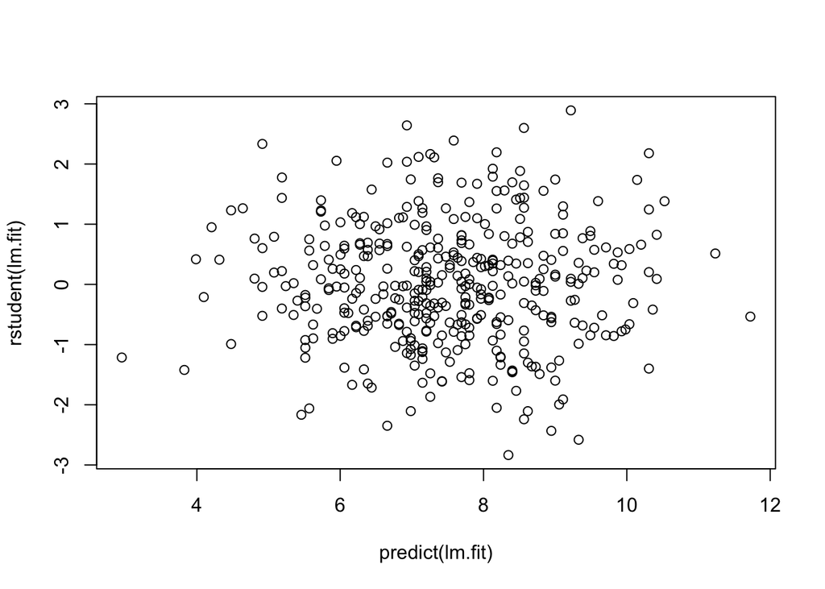

```r
plot(predict(lm.fit), rstudent(lm.fit))
```

All studentized residuals appear to be bounded by -3 to 3, so no potential outliers are suggested from the linear regression.

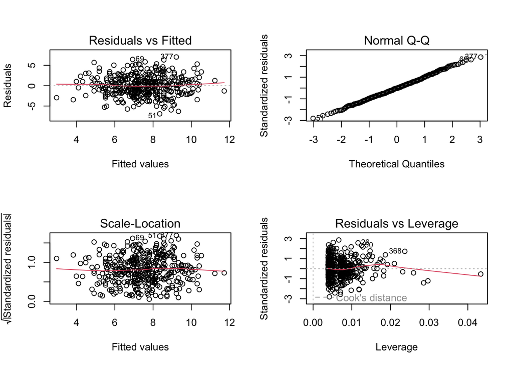

```r
par(mfrow = c(2, 2))
plot(lm.fit)
```

There are a few observations that greatly exceed $(p+1)/n$ (`0.0075567`) on the leverage-statistic plot that suggest that the corresponding points have high leverage.

## Exercise 4.3 (Optional)

In this exercise you will create some simulated data and will fit simple linear regression models to it. Make sure to use `set.seed(1)` prior to starting part (a) to ensure consistent results.

1. Using the `rnorm()` function, create a vector, `x`, containing 100 observations drawn from a $N(0,1)$ distribution. This represents a feature, `X`.

```r
set.seed(1)


x <- rnorm(100, 0, 1)
```

```r
eps <- rnorm(100, 0, 0.25)
```

3. Using `x` and `eps`, generate a vector `y` according to the model
   $$Y =
   -1 + 0.5X + \epsilon$$
   What is the length of the vector `y`? What are the values of $\beta_0$ and $\beta_1$ in this linear model?

`y` is a vector of equal length to `x` (a.k.a. 100 observations). $\beta_0 = -1$ and $\beta_1 = 0.5$.

```r
y <- -1 + 0.5*x + eps

length(y)
```

```
## [1] 100
```

4. Create a scatterplot displaying the relationship between `x` and `y`. Comment on what you observe.

There is a clear linear and positive relationship between `x` and `y`.

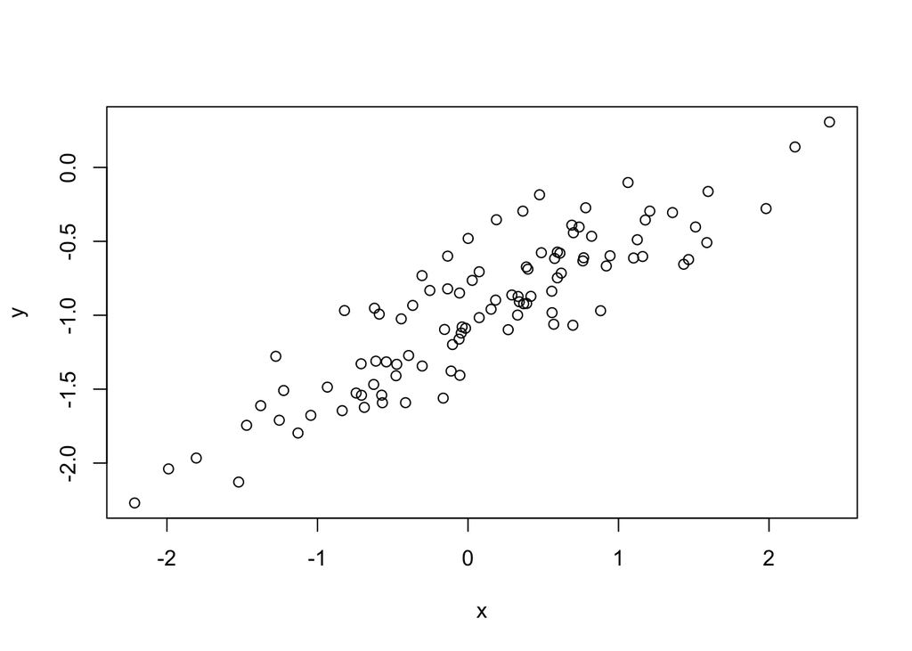

```r
plot(x, y)
```

5. Fit a least squares linear model to predict `y` using `x`. Comment on the model obtained. How do $\hat{\beta}_0$ and $\hat{\beta}_1$ compare to $\beta_0$ and $\beta_1$?

$\hat{\beta}_0$ and $\hat{\beta}_1$ very closely approximate $\beta_0$ and $\beta_1$ but are not quite identical.

```r
lm.fit <- lm(y ~ x)

summary(lm.fit)
```

```
##
## Call:
## lm(formula = y ~ x)
##
## Residuals:
##      Min       1Q   Median       3Q      Max
## -0.46921 -0.15344 -0.03487  0.13485  0.58654
##
## Coefficients:
##             Estimate Std. Error t value Pr(>|t|)
## (Intercept) -1.00942    0.02425  -41.63   <2e-16 ***
## x            0.49973    0.02693   18.56   <2e-16 ***
## ---
## Signif. codes:  0 '***' 0.001 '**' 0.01 '*' 0.05 '.' 0.1 ' ' 1
##
## Residual standard error: 0.2407 on 98 degrees of freedom
## Multiple R-squared:  0.7784, Adjusted R-squared:  0.7762
## F-statistic: 344.3 on 1 and 98 DF,  p-value: < 2.2e-16
```

6. Display the least squares line on the scatterplot obtained in (d). Draw the population regression line on the plot, in a different color. Use the `legend()` command to create an appropriate legend.

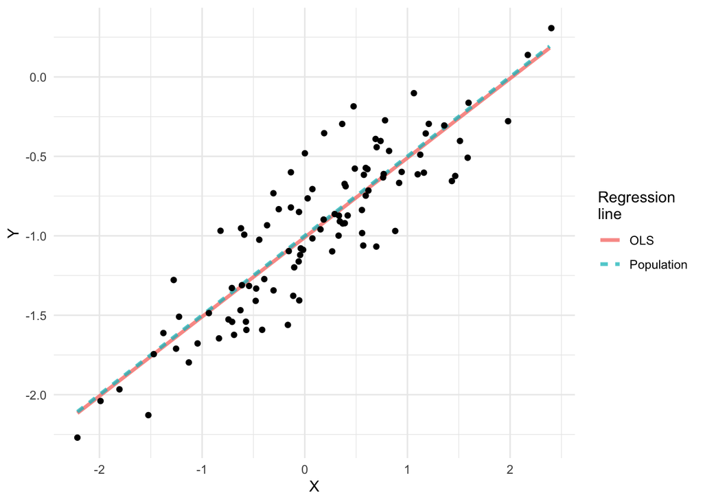

```r
tbl <- tibble(x, y)

sim.data <- tibble(x = seq(min(tbl$x), max(tbl$x), 0.1)) %>%
  mutate(OLS = predict(lm.fit, newdata = .),
         Population = -1 + 0.5*x) %>%
  pivot_longer(-x, names_to = 'line', values_to = 'estimate')

ggplot() +
  geom_line(data = sim.data, aes(x, estimate, colour = line, linetype = line), linewidth = 1.25, alpha = 0.75) +
  geom_point(data = tbl, aes(x = x, y = y)) +
  theme_minimal() +
  labs(x = 'X', y = 'Y', colour = 'Regression\nline', linetype = 'Regression\nline')
```

7. Now fit a polynomial regression model that predicts $y$ using $x$ and $x^2$. Is there evidence that the quadratic term improves the model fit? Explain your answer.